# Environmental parameters - analysis & variable selection

[output not shown]

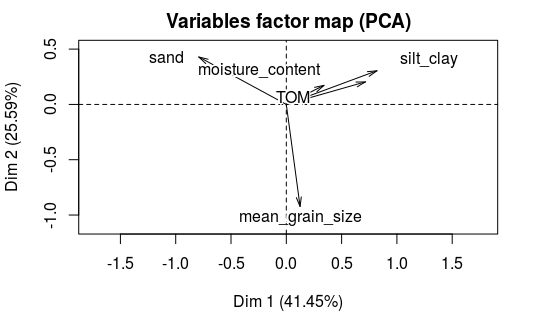

````r
```r
```r
Investigate(sediments.zostera.red.pca,
            file = \pca_sediments_zostera_red_report.Rmd\, document = \html_document\,
            out.selec = FALSE, # NB if outlier detection is performed, the function fails miserably, and I can't see a way to fix it
            remove.temp = TRUE)
````

Here - no luck again: too little variability is explained by the PCs - no real information carried by this PCA, either.  
Save for posterity anyway.

````r
```r
```r
write_rds(sediments.zostera.red.pca,
          here(save.dir, \pca_sediments_zostera_red.RDS\))
````

Try again, but without reducing the dataset prior to the PCA - without excluding highly correlated variables.

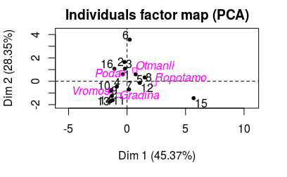

````r
```r
```r
## scale and center the dataset
sediments.zostera.all.scaled <- scale(sediments.zostera.all %>% select(TOM:silt_clay),
                                      center = TRUE, scale = TRUE)
sediments.zostera.all.scaled <- bind_cols(sediments.zostera.all %>% select(station),
                                          as.tibble(sediments.zostera.all.scaled))
sediments.zostera.all.pca <- PCA(sediments.zostera.all.scaled, scale.unit = FALSE, quali.sup = 1)
````

```
-- creation of the .Rmd file (time spent : 0s) --

-- analysis of the inertia (time spent : 0.01s) --
2 component(s) carrying information : total inertia of 73.7%

-- components description (time spent : 3.14s) --
plane 1:2
Chi-squared approximation may be incorrect

-- classification (time spent : 3.58s) --
Chi-squared approximation may be incorrect
8 clusters

-- annexes writing (time spent : 3.87s) --

-- saving data (time spent : 4.04s) --

-- outputs compilation (time spent : 4.05s) --
xdg-open: unexpected argument 'Passport/rabota/documents/phd/thesis/4-results-discussion/data-n-analyses/results-analysis/pca_sediments_zostera_all_report.html'
Try 'xdg-open --help' for more information.
-- task completed (time spent : 13.67s) --
This interpretation of the results was carried out automatically,
it cannot match the quality of a personal interpretation
```

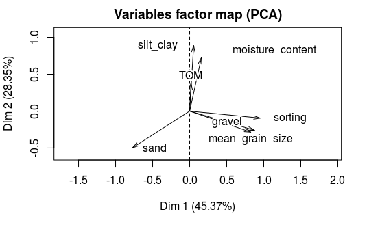

````r
```r
```r
Investigate(sediments.zostera.all.pca,
            file = \pca_sediments_zostera_all_report.Rmd\, document = \html_document\,
            out.selec = FALSE, # NB if outlier detection is performed, the function fails, and I can't see a way to fix it
            remove.temp = TRUE)
````

So now the PCA is at least valid, but the stations are still not represented well enough - not surprising, with so little data.. Save in case it’s needed.

````r
```r
```r
write_rds(sediments.zostera.all.pca,
          here(save.dir, \pca_sediments_zostera_all.RDS\))
````

OK, one more: **seagrass parameters - again, using all available data**.  
Import seagrass data.

````r
```r
```r
## import the non-summarized data first
(seagrass.all <- read_csv(here(save.dir, \seagrass_all_stations.csv\))
 )
```r
```r
## remove the number from the station names
seagrass.all.clean <- seagrass.all %>%
  mutate(station = str_extract(station, \[^\\d]+\))
## filter only the 2013-2014 stations and convert station to factor
(seagrass.all.clean <- seagrass.all.clean %>%
    filter(station %in% c(\Poda\, \Otmanli\, \Vromos\, \Gradina\, \Ropotamo\)) %>%
    mutate(station = factor(station, levels = c(\Poda\, \Otmanli\, \Vromos\, \Gradina\, \Ropotamo\))) %>%
    arrange(station)
)
````

| station | year | replicate | shoot_count | ag_biomass_wet | bg_biomass_wet |
| --- | --- | --- | --- | --- | --- |
| Poda | 2013 | 1 | 146 | 56.88 | 13.11 |
| Poda | 2013 | 2 | 187 | 76.64 | 15.82 |
| Poda | 2013 | 3 | 147 | 50.83 | 24.26 |
| Poda | 2013 | 4 | 147 | 53.56 | 13.15 |
| Poda | 2013 | 5 | 188 | 63.38 | 12.40 |
| Poda | 2013 | 1 | 265 | 132.63 | 26.81 |
| Poda | 2013 | 2 | 273 | 98.13 | 41.45 |
| Poda | 2013 | 4 | 187 | 61.20 | 32.42 |
| Poda | 2013 | 5 | 150 | 77.03 | 30.74 |
| Poda | 2014 | 1 | 147 | 51.30 | 21.33 |

[output cut: 78 more lines]

````r
```r
```r
## calculate the correlation matrix (on the numeric variables only)
seagrass.all.cors <- cor(seagrass.all.clean %>% select(-c(station:replicate)))

## find and eliminate the highly correlated variables. NB names = FALSE, to return column index
highly.cor.seagrass.all <- findCorrelation(seagrass.all.cors, cutoff = 0.85)
(seagrass.red <- seagrass.all.clean %>%
    select(-c(station:replicate)) %>% # otherwise column indices don't match
    select(-highly.cor.seagrass.all)
)
````

| shoot_count | ag_biomass_wet | bg_biomass_wet |
| --- | --- | --- |
| 146 | 56.88 | 13.11 |
| 187 | 76.64 | 15.82 |
| 147 | 50.83 | 24.26 |
| 147 | 53.56 | 13.15 |
| 188 | 63.38 | 12.40 |
| 265 | 132.63 | 26.81 |
| 273 | 98.13 | 41.45 |
| 187 | 61.20 | 32.42 |
| 150 | 77.03 | 30.74 |
| 147 | 51.30 | 21.33 |

[output cut: 78 more lines]

All right - apparently the seagrass parameters are not so inter-correlated after all…

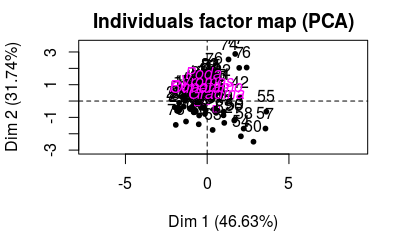

````r
```r
```r
## scale and center the reduced dataset
seagrass.red.scaled <- scale(seagrass.red,
                             center = TRUE, scale = TRUE)
seagrass.red.scaled <- bind_cols(seagrass.all.clean %>% select(station),
                                 as.tibble(seagrass.red.scaled))
seagrass.red.pca <- PCA(seagrass.red.scaled, scale.unit = FALSE, quali.sup = 1)
````

```
-- creation of the .Rmd file (time spent : 0s) --

-- analysis of the inertia (time spent : 0.02s) --
1 component(s) carrying information : total inertia of 46.6%

-- components description (time spent : 3.17s) --
dim. 1
Chi-squared approximation may be incorrect

-- classification (time spent : 3.46s) --
Chi-squared approximation may be incorrect
3 clusters

-- annexes writing (time spent : 3.67s) --

-- saving data (time spent : 3.7s) --

-- outputs compilation (time spent : 3.71s) --
xdg-open: unexpected argument 'Passport/rabota/documents/phd/thesis/4-results-discussion/data-n-analyses/results-analysis/pca_seagrass_params_zostera_red_report.html'
Try 'xdg-open --help' for more information.
-- task completed (time spent : 10.75s) --
This interpretation of the results was carried out automatically,
it cannot match the quality of a personal interpretation
```

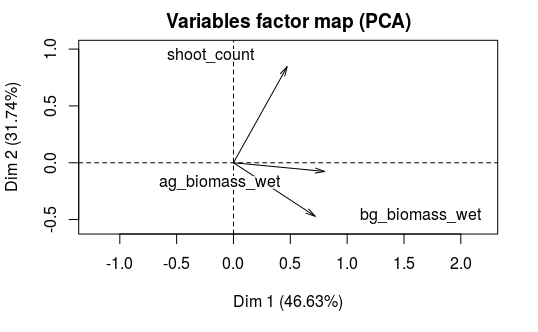

````r
```r
```r
Investigate(seagrass.red.pca,
            file = \pca_seagrass_params_zostera_red_report.Rmd\, document = \html_document\,
            out.selec = FALSE, # NB if outlier detection is performed, the function fails miserably, and I can't see a way to fix it
            remove.temp = TRUE)
````

Not informative - doesn’t explain enough of the observed variability. The variability explained by PC1 **is** significant - but only marginally so; probably better not to interpret this analysis at all.

Save this one, too.

````r
```r
```r
write_rds(seagrass.red.pca,
          here(save.dir, \pca_seagrass_red.RDS\))
````

###### **Elastic net - seagrasses 2013-14.**

Learning from the sand stations, I’ll try it on the raw (non-summarized) data.  
Starting with water column crap.

````r
```r
```r
## transform station to factor
water.zostera.all <- water.zostera.all %>%
  mutate(station = factor(station, levels = c(\Poda\, \Otmanli\, \Vromos\, \Gradina\, \Ropotamo\)))

## perform the elastic net shit, excluding the Secchi depth - too many missing values
en.water.st.zostera <- glmnet(x = as.matrix(water.zostera.all %>% select(chl_a:seston)),
                           y = water.zostera.all %>% pull(station),
                           family = \multinomial\, type.multinomial = \grouped\)

plot(en.water.st.zostera, xvar = \lambda\, label = TRUE, type.coef = \2norm\)


cvfit.water.st.zostera <- cv.glmnet(x = as.matrix(water.zostera.all %>% select(chl_a:seston)),
                                 y = water.zostera.all %>% pull(station),
                                 family=\multinomial\, type.multinomial = \grouped\)

plot(cvfit.water.st.zostera)
````

Again, multiple complaints - see part about sediments in sand stations. Probably come from insufficent replication.

Let’s see which variables are the most important according to the elastic net.

````r
```r
```r
coef(en.water.st.zostera, s = cvfit.water.st.zostera$lambda.min)
````

````r
```r
```r
summary(glm(as.numeric(station) ~ seston, data = water.zostera.all))
````

````r
```r
```r
summary(glm(as.numeric(station) ~ chl_a + Ninorg + NH4 + NO3 + Ntotal + PO4 + seston, data = water.zostera.all))
````

OK - let’s try again with the **sediment parameters minus the heavy metals**.  
In this case, I am going to go back and look at the sediment data for the rest of the stations (there were 2 stations in each seagrass meadow at each sampling, and there is data for those, too).

````r
```r
```r
## using all available sediment data
en.sediments.st.zostera <- glmnet(x = as.matrix(sediments.zostera.all %>% select(TOM:silt_clay)),
                           y = sediments.zostera.all %>% pull(station),
                           family = \multinomial\, type.multinomial = \grouped\)

plot(en.sediments.st.zostera, xvar = \lambda\, label = TRUE, type.coef = \2norm\)

# cvfit.sediments.st.zostera <- cv.glmnet(x = as.matrix(sediments.zostera.all %>% select(TOM:silt_clay)),
#                                  y = sediments.zostera.all %>% pull(station),
#                                  family=\multinomial\, type.multinomial = \grouped\)
#
# plot(cvfit.sediments.st.zostera)
````

It still complains, doesn’t want to assess the fit. I’m going to exclude Vromos and Ropotamo (only 2 observations each) and see if that changes anything..

````r
```r
```r
## filter out Vromos and Ropotamo
(sediments.zostera.all.sub <- sediments.zostera.all %>%
   filter(station != \Ropotamo\, station != \Vromos\) %>%
   mutate(station = factor(station, levels = c(\Poda\, \Otmanli\, \Gradina\)))
)


en.sediments.st.zostera.2 <- glmnet(x = as.matrix(sediments.zostera.all.sub %>%  select(TOM:silt_clay)),
                                    y = sediments.zostera.all.sub %>% pull(station),
                                    family = \multinomial\, type.multinomial = \grouped\)

plot(en.sediments.st.zostera.2, xvar = \lambda\, label = TRUE, type.coef = \2norm\)

cvfit.sediments.st.zostera.2 <- cv.glmnet(x = as.matrix(sediments.zostera.all.sub %>% select(TOM:silt_clay)),
                                          y = sediments.zostera.all.sub %>% pull(station),
                                          family=\multinomial\, type.multinomial = \grouped\)

plot(cvfit.sediments.st.zostera.2)
````

Well wouldn’t you know it - it works this time (with 3 out of the 5 stations)!  
Check out to which parameters we owe this immense honor..

````r
```r
```r
coef(en.sediments.st.zostera.2, s = cvfit.sediments.st.zostera.2$lambda.min)
````

````r
```r
```r
summary(glm(as.numeric(as.factor(station)) ~ TOM + moisture_content + sorting + silt_clay, data = sediments.zostera.all.sub))
````

Let’s play with the **seagrass parameters**. I’m not holding my breath, though.

Perform the elastic net variable selection.

````r
```r
```r
en.seagrass.st.zostera <- glmnet(x = as.matrix(seagrass.all.clean %>%  select(shoot_count:bg_biomass_wet)),
                                 y = seagrass.all.clean %>% pull(station),
                                 family = \multinomial\, type.multinomial = \grouped\)

plot(en.seagrass.st.zostera, xvar = \lambda\, label = TRUE, type.coef = \2norm\)

cvfit.seagrass.st.zostera <- cv.glmnet(x = as.matrix(seagrass.all.clean %>% select(shoot_count:bg_biomass_wet)),
                                       y = seagrass.all.clean %>% pull(station),
                                       family=\multinomial\, type.multinomial = \grouped\)

plot(cvfit.seagrass.st.zostera)
````

````r
```r
```r
summary(glm(as.numeric(as.factor(station)) ~ shoot_count + ag_biomass_wet + bg_biomass_wet, data = seagrass.all.clean))
````

**For seagrass samples, it looks like there are too few observations of the environmental parameters for us to be able to apply the elastic net method of variable selection. For that matter, the PCA on these parameters is not really meaningful either, esp. for the sediments.**

##### Sozopol Bay, 2012

Starting with the water column parameters. Here at least there are some more - thanks to the 2009-2011 project.  
However, I am going to work with the non-summarized data, because I don’t have any more nerves for invalid analyses.

````r
```r
```r
## from the long-term non-summarized water column parameters
(water.2012 <- water.all %>%
    filter(station %in% c(\Konski\, \Ribka\, \Gradina\))
)
````

There is no point to add LUSI here - the entire Sozopol Bay falls within one watershed, so only one value.

````r
```r
```r
## scale and center the data (different units), and add back the stations
water.2012.scaled <- scale(water.2012 %>% select(chl_a:secchi), center = TRUE, scale = TRUE)

water.2012.scaled <- bind_cols(water.2012 %>% select(station),
                               as.tibble(water.2012.scaled))

## make station a factor
water.2012.scaled <- water.2012.scaled %>%
  mutate(station = factor(station, levels = c(\Konski\, \Ribka\, \Gradina\))) %>%
  arrange(station)

## perform PCA with FactoMineR - it's equivalent to the base version, anyway, but the visualization expects a particular structure of the results, so easier to do it this way.
water.2012.pca <- PCA(water.2012.scaled,
                      scale.unit = FALSE,
                      quali.sup = 1,
                      graph = FALSE)

## display the summary and biplot
summary(water.2012.pca)

(plot.water.2012.pca <- fviz_pca_biplot(water.2012.pca, axes = c(1, 2),
                                        label = \var\,
                                        col.var = \cos2\, gradient.cols = c(\skyblue\, \navyblue\, \red\),
                                        repel = TRUE)
)
````

This, however, is without first filtering the very much correlated variables.

Generate a report on the PCA with FactoInvestigate.

````r
```r
```r
# Investigate(water.2012.pca, file = \pca_water_2012_report.Rmd\, document = \html_document\, remove.temp = TRUE)
````

OK this bullshit doesn’t work, I don’t know why and I don’t care - something to do with outlier detection. That’s why I hate complicated black box functions.  
Moving right along to elastic net, which I would trust more in any case.

````r
```r
```r
## filter out one row with NaN in NH4
water.2012.sub <- water.2012 %>%
  filter(!is.nan(NH4))

en.water.st.2012 <- glmnet(x = as.matrix(water.2012.sub %>% select(chl_a:seston)),
                           y = water.2012.sub %>% pull(station),
                           family = \multinomial\)

plot(en.water.st.2012, xvar = \lambda\, label = TRUE, type.coef = \2norm\)

## check the fit
cvfit.water.st.2012 <- cv.glmnet(x = as.matrix(water.2012.sub %>% select(chl_a:seston)),
                                 y = water.2012.sub %>% pull(station),
                                 family=\multinomial\)

plot(cvfit.water.st.2012)
````

````r
```r
```r
coef(en.water.st.2012, s = cvfit.water.st.2012$lambda.min)
````

##### **Additional PCA visualizations**

Visualize - more clearly - some of the stupid, stupid, useless PCAs.  
###### Sand stations - Burgas Bay (2013-14)

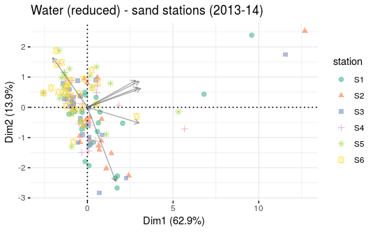

I think **this one** will make it into the results section..

[output not shown]

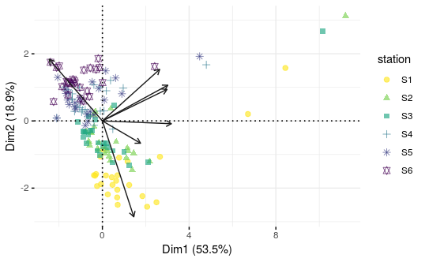

````r
```r
```r
(plot.water.sand.all.LUSI.red.pca <- plot.water.sand.all.LUSI.red.pca +
    ## better point shapes + labels for legend
    scale_shape_manual(values = c(19, 17, 15, 3, 8, 11),
                       labels = paste0(\S\, as.numeric((unique(water.sand.all.LUSI.red.scaled$station))))) +
    ## better colour scheme for points + labels for legend
    scale_color_viridis(discrete = TRUE,
                        option = \viridis\,
                        direction = -1,
                        labels = paste0(\S\, as.numeric((unique(water.sand.all.LUSI.red.scaled$station)))))
)
````

Save this plot..

````r
```r
```r
ggsave(here(figures.dir, \pca_water_LUSI_sand.png\),
       plot.water.sand.all.LUSI.red.pca,
       width = 15, units = \cm\, dpi = 300)
````

```
Saving 15 x 17.8 cm image
```

Ok now for consistency make this plot again with the old colour scheme (Set 2 from RColorBrewer). I’ll decide later which one to use.

```
'colour', which will replace the existing scale.
```

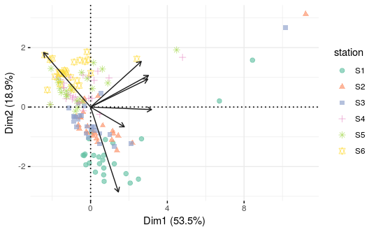

````r
```r
```r
(plot.water.sand.all.LUSI.red.pca2 <- plot.water.sand.all.LUSI.red.pca +
    ## colour scheme for points + labels for legend
    scale_color_brewer(palette = \Set2\,
                       labels = paste0(\S\, as.numeric((unique(water.sand.all.LUSI.red.scaled$station)))))
)
````

For some strange reason, the first plot is very high (17.8 cm), while the second one is only 8.8 cm.. Some weird aspect ratio thingie, although the only difference is the colours.

Plot the qualitative variable map - to see what it looks like and if it’s worth including in the results at all.

````r
```r
```r
## the data we need from the PCA result is the coordinates of the supplementary qualitative variable on the first two PCs.
## NB we also want them in a nice tibble, so we need to make sure to keep the row names
qual.coord.sand <- rownames_to_column(as.data.frame(water.sand.all.LUSI.red.pca$quali.sup$coord), var = \station\)
(qual.coord.sand <- qual.coord.sand %>%
    ## only keep the first 2 PCs in this case...
    select(station, Dim.1, Dim.2) %>%
    ## ..and recode station, to make plotting less painful
    mutate(station = recode(station,
                            Kraimorie = \S1\, Chukalya = \S2\, Akin = \S3\,
                            Sozopol = \S4\, Agalina = \S5\, Paraskeva = \S6\)) %>%
    ## make station a factor..
    mutate(station = factor(station,
                            levels = c(\S1\, \S2\, \S3\, \S4\, \S5\, \S6\)))
)
````

```
Saving 15 x 8.81 cm image
```

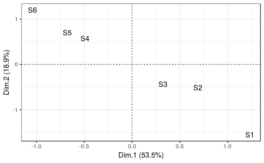

| station | Dim.1 | Dim.2 |
| --- | --- | --- |
| S1 | 1.2291102 | -1.5547439 |
| S2 | 0.6879932 | -0.5146933 |
| S3 | 0.3233064 | -0.4327173 |
| S4 | -0.4962857 | 0.5683412 |
| S5 | -0.6787915 | 0.7040132 |
| S6 | -1.0454811 | 1.2070664 |

```r
## make the axis labels (PC + % explained variance)
lab.x <- paste0(\Dim.1 \, \(\,
                round(water.sand.all.LUSI.red.pca$eig[\comp 1\, \percentage of variance\], digits = 1),
                \%)\)
lab.y <- paste0(\Dim.2 \, \(\,
                round(water.sand.all.LUSI.red.pca$eig[\comp 2\, \percentage of variance\], digits = 1),
                \%)\)

## plot them..
(plot.qual.map.water.sand.LUSI.pca <- ggplot(qual.coord.sand,
                                             aes(x = Dim.1, y = Dim.2)) +
    geom_text(label = qual.coord.sand$station) +
    geom_hline(yintercept = 0, linetype = \dotted\) +
    geom_vline(xintercept = 0, linetype = \dotted\) +
    labs(x = lab.x, y = lab.y)
)
## save, in case needed separately
ggsave(here(figures.dir, \pca_qual_water_LUSI_sand.png\),
       plot.qual.map.water.sand.LUSI.pca,
       width = 15, units = \cm\, dpi = 300)
```

Combine the PCA water parameter plots for the sand stations (library cowplot)..

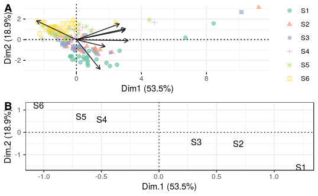

````r
```r
```r
cowplot::plot_grid(plot.water.sand.all.LUSI.red.pca2,
                                                    plot.qual.map.water.sand.LUSI.pca,
                                                    axis = \b\, nrow = 2,
                                                    labels = c(\A\, \B\), rel_widths = 5.5)
````

Ok, I don’t like it… The axes dont’ match too well. I’ll just insert them as sequential figures.

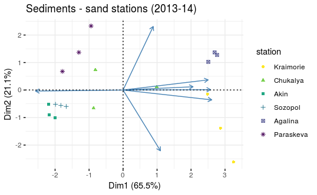

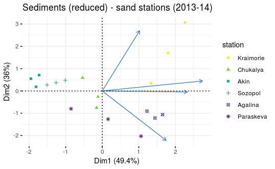

###### Seagrass stations - Burgas Bay (2013-14)

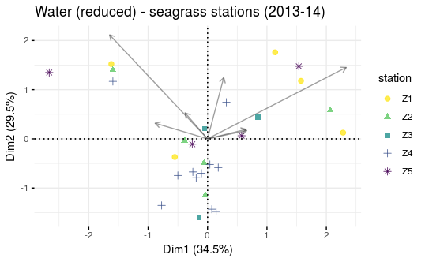

And **this one** is also going to the results section..

[output not shown]

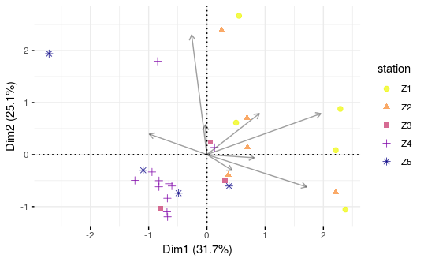

````r
```r
```r
(plot.water.zostera.LUSI.red.pca <- plot.water.zostera.LUSI.red.pca +
    ## change point shapes - make them more distinguishable
    scale_shape_manual(values = c(19, 17, 15, 3, 8),
                       labels = paste0(\Z\, as.numeric((unique(water.zostera.LUSI.red.scaled$station))))) +
    ## pretty colours
    scale_color_viridis(discrete = TRUE,
                        option = \plasma\,
                        direction = -1,
                        labels = paste0(\Z\, as.numeric((unique(water.zostera.LUSI.red.scaled$station)))))
)
````

Save..

````r
```r
```r
ggsave(here(figures.dir, \pca_water_LUSI_zostera.png\),
       plot.water.zostera.LUSI.red.pca,
       width = 15, units = \cm\, dpi = 300)
````

Now again with the old station colour scheme..

```
'colour', which will replace the existing scale.
```

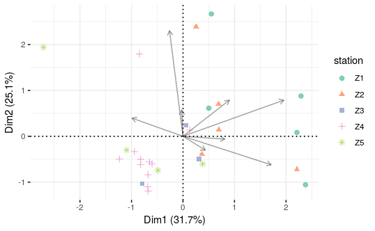

````r
```r
```r
(plot.water.zostera.LUSI.red.pca2 <- plot.water.zostera.LUSI.red.pca +
    ## old brewer colour scheme
    scale_color_brewer(palette = \Set2\,
                       labels = paste0(\Z\, as.numeric((unique(water.zostera.LUSI.red.scaled$station)))))
)
````

Again with the aspect ratio… hm!

Plot the qualitative variable map for the seagrass samples, too.

````r
```r
```r
## the data we need from the PCA result is the coordinates of the supplementary qualitative variable on the first two PCs.
## NB we also want them in a nice tibble, so we need to make sure to keep the row names
qual.coord.zostera <- rownames_to_column(as.data.frame(water.zostera.LUSI.red.pca$quali.sup$coord), var = \station\)
(qual.coord.zostera <- qual.coord.zostera %>%
    ## only keep the first 2 PCs in this case...
    select(station, Dim.1, Dim.2) %>%
    ## ..and recode station, to make plotting less painful
    mutate(station = recode(station,
                            Poda = \Z1\, Otmanli = \Z2\, Vromos = \Z3\,
                            Gradina = \Z4\, Ropotamo = \Z5\)) %>%
    ## make station a factor..
    mutate(station = factor(station,
                            levels = c(\Z1\, \Z2\, \Z3\, \Z4\, \Z5\)))
)
````

```
Saving 15 x 8.81 cm image
```

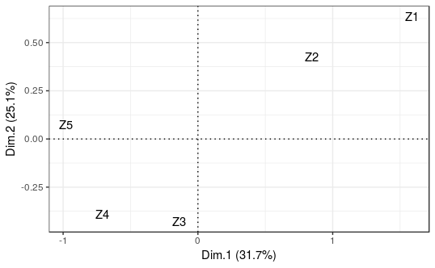

| station | Dim.1 | Dim.2 |
| --- | --- | --- |
| Z1 | 1.5869461 | 0.63723819 |
| Z2 | 0.8444714 | 0.42461048 |
| Z3 | -0.1397014 | -0.42951433 |
| Z4 | -0.7118208 | -0.39234270 |
| Z5 | -0.9769887 | 0.07376734 |

```r
## make the axis labels (PC + % explained variance)
lab.x.zostera <- paste0(\Dim.1 \, \(\,
                round(water.zostera.LUSI.red.pca$eig[\comp 1\, \percentage of variance\], digits = 1),
                \%)\)
lab.y.zostera <- paste0(\Dim.2 \, \(\,
                round(water.zostera.LUSI.red.pca$eig[\comp 2\, \percentage of variance\], digits = 1),
                \%)\)

## plot them..
(plot.qual.map.water.zostera.LUSI.pca <- ggplot(qual.coord.zostera,
                                             aes(x = Dim.1, y = Dim.2)) +
    geom_text(label = qual.coord.zostera$station) +
    geom_hline(yintercept = 0, linetype = \dotted\) +
    geom_vline(xintercept = 0, linetype = \dotted\) +
    labs(x = lab.x.zostera, y = lab.y.zostera)
)
## save, in case needed separately
ggsave(here(figures.dir, \pca_qual_water_LUSI_zostera.png\),
       plot.qual.map.water.zostera.LUSI.pca,
       width = 15, units = \cm\, dpi = 300)
```

Make a nice table with the PCA outputs.  
First, get the data we want: the PCs eigenvalues, the proportion explained variance and the cumulative explained variance, the variable loadings (= correlations with the PCs), and the cos2 (= quality of representation of the variables on the PCs).

````r
```r
```r
## helper function to extract an reformat only the parts of the PCA result I want..
extract_pca_results <- function(pca.res, comp = 2, var = c(\cor\, \contrib\, \cos2\, \coord\)) {
  ## Extracts the PCA characteristics & the variable parameters from a PCA object created by FactoMineR.
  ## Dependencies: tidyverse

  ## get eigenvalues (= variance) & % variance explained. Matrix needs to be transposed (to have PCs in columns)
  pca.eig <- t(pca.res$eig)

  ## extract variable components
  pca.var <- lapply(var, function(x) pca.res$var[[x]])
  ## fix the names
  names(pca.var) <- var

  ## add eigenvalues and variable characteristics to an output list
  pca.out <- c(eig = list(pca.eig), pca.var)
  ## convert all elements of the output list to tibble, keeping the row names in the first column
  pca.out.df <- lapply(pca.out, function(x) rownames_to_column(as.data.frame(x)))

  ## fix the column names
  pca.out.df <- lapply(pca.out.df, function(x) {
    names(x) %<>%
      gsub(pattern = \comp \, replacement = \PC\, x = .) %>%
      gsub(pattern = \Dim.\, replacement = \PC\, x = .)
    return(x)
    })

  ## subset to whatever number of PCs is specified
  pca.out.df.sub <- lapply(pca.out.df, function(x) {
    x <- x %>% select(1:(comp + 1)) # first column is the rownames, then PCs in order
    return(x)
    })

  ## output
  return(pca.out.df.sub)

  }
## this is the data extracted from the water column+LUSI PCA in seagrass..
(table.data.water.zostera.all.LUSI.pca <- extract_pca_results(water.zostera.LUSI.red.pca,
                                                              comp = 3,
                                                              var = c(\cor\, \contrib\))
)
````

| rowname | PC1 | PC2 | PC3 |
| --- | --- | --- | --- |
| eigenvalue | 1.383065 | 1.095564 | 0.8675586 |
| percentage of variance | 31.657077 | 25.076435 | 19.8576085 |
| cumulative percentage of variance | 31.657077 | 56.733512 | 76.5911205 |

```
NA
```

| rowname | PC1 | PC2 | PC3 |
| --- | --- | --- | --- |
| chl_a | 0.66245480 | -0.24037062 | 0.6917754 |
| NH4 | 0.46205790 | 0.40412802 | 0.1655789 |
| NO3 | -0.03220627 | 0.69670810 | 0.1451338 |
| Ntotal | -0.10414685 | 0.91550624 | 0.2667064 |
| PO4 | 0.48539634 | -0.33827870 | 0.3445815 |
| seston | 0.57289017 | -0.04280934 | -0.1606363 |
| secchi | -0.55242192 | 0.22008067 | 0.4063651 |
| LUSI | 0.77230045 | 0.31040960 | -0.4833194 |

| rowname | PC1 | PC2 | PC3 |
| --- | --- | --- | --- |
| chl_a | 30.931117942 | 5.14103922 | 53.7721276 |
| NH4 | 8.576036214 | 8.28202925 | 1.7556904 |
| NO3 | 0.007381021 | 4.36055951 | 0.2389551 |
| Ntotal | 0.723954621 | 70.62309162 | 7.5688492 |
| PO4 | 1.982649019 | 1.21564616 | 1.5928709 |
| seston | 6.952204819 | 0.04900743 | 0.8713865 |
| secchi | 10.347538927 | 2.07330926 | 8.9263108 |
| LUSI | 40.479117437 | 8.25531755 | 25.2738095 |

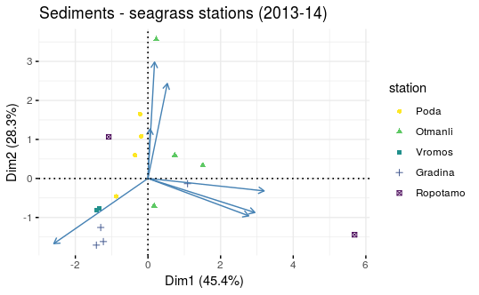

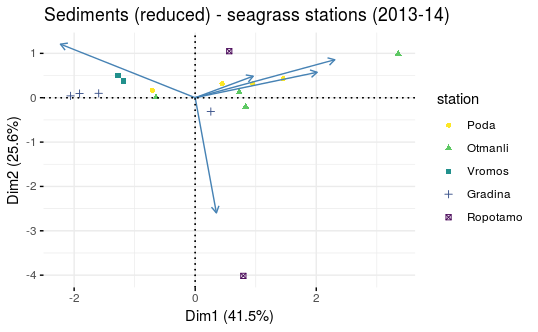

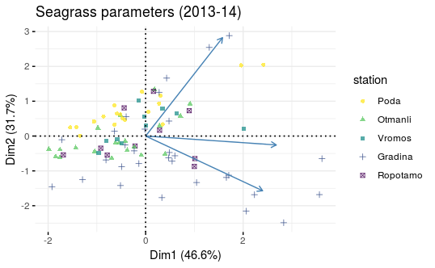

###### **Sidebar: PCA result exploration - demonstrated on water parameters on sand stations, 2013-14**

PCA done like this is meaningless.  
However, let’s explore the results a bit - just to demonstrate the basic procedure with PCA quality checks & interpretation.  
1) Check the variances of the principal components. Amount of variation retained by each PC = eigenvalue. First PC = direction with maximum amount of variation in the dataset.

````r
```r
```r
water.sand.pca.fin$eig
````

2. Visualize the importance of the PCs (-> scree plot).

````r
```r
```r
fviz_screeplot(water.sand.pca.fin)
````

3. Plot correlations/loadings of the variables with the PCs = variable loadings. Variables can be plotted as points in the component space using their loadings as coordinates.

````r
```r
```r
## look at variable coordinates on each PC
water.sand.pca.fin$var$coord

## visualize the variables on the factor map. Correlation circle can help visualize the most correlated variables (variables that group together).
fviz_pca_var(water.sand.pca.fin, col.circle = \grey\)
````

4. Explore the quality of the representation for variables on the factor map (cos2 = squared loadings for variables = cor x cor = coord x coord). The closer a variable to the circle of correlations, the better its representation on the factor map, and the more important it is to interpret these components. If a variable is perfectly represented by only 2 components, the sum of the cos2 = 1, and the variables will be positioned on the circle of correlations. For some variables - more than 2 components required to perfectly represent the data; then - variables positioned inside circle of correlations. Variables close to the center of the plot - less important for the first components.

````r
```r
```r
## check the variables with highest correlation to the first few PCs
as_tibble(water.sand.pca.fin$var$cos2, rownames = \var\) %>%
  arrange(desc(Dim.1))

## plot the variables factor map, and color the vectors according to the amount of correlation to the PCs. Can select the minimum value of cos2 and the PC axes to plot.
# PC1-PC2
fviz_pca_var(water.sand.pca.fin, axes = c(1, 2), select.var = list(cos2 = 0.5),
             col.var = \cos2\, gradient.cols = c(\skyblue\, \navyblue\, \red\))

# PC1-PC3
fviz_pca_var(water.sand.pca.fin, axes = c(1, 3), select.var = list(cos2 = 0.5),
             col.var = \cos2\, gradient.cols = c(\skyblue\, \navyblue\, \red\))
````

5. Check the contributions of the variables to the PCs. Variables that are correlated with PC1 and PC2 - the most important in explaining the variability in the dataset.  
   Variables not correlated with any PC or correlated with the last dimensions - low contribution; could be removed to simplify overall analysis.  
   % contribution of a variable in accounting for the variability in a given PC = (variable.cos2 x 100) / (total cos2 of component)

````r
```r
```r
as_tibble(water.sand.pca.fin$var$contrib, rownames = \var\) %>%
  arrange(desc(Dim.1))
````

6. Visualize the most important variables associated with a given PC. The red line on the graph represents the expected average contribution (if all variable contributions were uniform). For a given component, any variable with contribution larger than that cutoff could be considered important.

````r
```r
```r
plot_pca_var_contrib <- function(pca.res, choice = c(\var\, \ind\), axes = c(start : end)) {
  ## helper for plotting variable/individuals contributions (as bars) to the specified PC axes.
  ## Dependencies: factoextra

  # plot contributions for each axis separately
  for(i in axes){
    print(fviz_contrib(pca.res, choice = choice, axes = i))
  }

  # plot the overall contributions to the specified axes
  print(fviz_contrib(pca.res, choice = choice, axes = axes))
}



# variable contributions on PC1, PC2 and PC3 (+ all 3 axes together)
plot_pca_var_contrib(water.sand.pca.fin,
                     choice = \var\,
                     axes = c(1:3))


# if there are many variables in the dataset, we can show only the top n contributing variables:
fviz_contrib(water.sand.pca.fin, choice = \var\, axes = 1, top = 5)
````

7. Color variables on the variable factor map according to their contributions - highlights the most important variables in explaining the variations retained by the PCs.

````r
```r
```r
fviz_pca_var(water.sand.pca.fin, col.var = \contrib\)

## variable contributions to PC1-2
fviz_pca_var(water.sand.pca.fin, axes = c(1, 2), col.var = \contrib\)
##..and to PC1-3
fviz_pca_var(water.sand.pca.fin, axes = c(1, 3), col.var = \contrib\)
````

8. Dimension description - identify the most correlated variables with a given PC -> but only works with more categories (e.g. replicates at the stations, years,..). I’m including it as a reminder that it exists as an option.

````r
```r
```r
# dimdesc(water.sand.pca.fin, axes = c(1:5))
````

9. Explore individuals (= stations/species/..) in the same way as the variables just now.

````r
```r
```r
## coordinates of individuals on the PCs
water.sand.pca.fin$ind$coord

## plot & label by station (can also colour by group - year,..)
fviz_pca_ind(water.sand.pca.fin, label = c(\quali\, \ind\))

## quality of representation for individuals on the PCs (cos2)
as_tibble(water.sand.pca.fin$ind$cos2, rownames = \ind\) %>%
  arrange(desc(Dim.1))

## correlation of individuals with PC1-2
fviz_pca_ind(water.sand.pca.fin, axes = c(1, 2), col.ind = \cos2\, gradient.cols = c(\skyblue\, \navyblue\, \red\))

## ...and with PC1-3
fviz_pca_ind(water.sand.pca.fin, axes = c(1, 3), col.ind = \cos2\, gradient.cols = c(\skyblue\, \navyblue\, \red\))

## contribution of individuals to the PCs
as_tibble(water.sand.pca.fin$ind$contrib, rownames = \ind\) %>%
  arrange(desc(Dim.1))

## visualize the most contributing individuals (stations) associated with a given PC
# PC1-3 + all 3 together (custom function)
plot_pca_var_contrib(water.sand.pca.fin,
                     choice = \ind\,
                     axes = c(1:3))

## top 3 individuals (stations) contributing to PC1 (for ex.)
fviz_contrib(water.sand.pca.fin, choice = \ind\, axes = 1, top = 3)

## individuals (stations) map colored according to their contribution
fviz_pca_ind(water.sand.pca.fin, col.ind = \contrib\)
````

Sidebar end.  
***